# References

- https://medium.com/@garora039/dimensionality-reduction-using-t-sne-effectively-cabb2cd519b
- http://brandonrose.org/clustering

# 1.0 Notebook Initialization

```python
##
# code repurposed from started code found in
# https://canvas.northwestern.edu/courses/112789/pages/twenty-newsgroups-vectorization-and-text-classification?module_item_id=1425573
##
import multiprocessing
import matplotlib.pyplot as plt
import matplotlib as mpl
import nltk
import numpy as np
import os  # for os.path.basename
import pandas as pd
import random
import re
import seaborn as sns
import string

from collections import Counter
from gensim.models import Word2Vec
from gensim.models.doc2vec import Doc2Vec, TaggedDocument
from nltk.corpus import stopwords
from nltk.stem import PorterStemmer
from pprint import pprint
from scipy.cluster.hierarchy import ward, dendrogram
from sklearn.cluster import KMeans
from sklearn.externals import joblib
from sklearn.metrics import plot_confusion_matrix
from sklearn.feature_extraction.text import TfidfVectorizer, CountVectorizer
from sklearn.preprocessing import StandardScaler
from sklearn.manifold import TSNE
from sklearn.ensemble import RandomForestClassifier
from sklearn import metrics
from sklearn.model_selection import train_test_split
from sklearn.metrics.pairwise import cosine_similarity
from sklearn.preprocessing import MinMaxScaler
from sklearn.manifold import MDS

nltk.download('stopwords')
stoplist = nltk.corpus.stopwords.words('english')

%config InlineBackend.print_figure_kwargs={'facecolor' : "w"}

DROP_STOPWORDS = True

# Functionality to turn stemming on or off
STEMMING = False  # judgment call, parsed documents more readable if False

MAX_NGRAM_LENGTH = 1  # try 1 for unigrams... 2 for bigrams... and so on
VECTOR_LENGTH = 200  # set vector length for TF-IDF and Doc2Vec
WRITE_VECTORS_TO_FILE = False
SET_RANDOM = 9999
```

## 1.2 User Functions

```python
# load doc into memory
def load_doc(filename):
    # open the file as read only
    file = open(filename, 'r')
    # read all text
    text = file.read()
    # close the file
    file.close()
    return text

# turn a doc into clean tokens


def clean_doc(doc):
    # split into tokens by white space
    tokens = doc.split(' ')
    # prepare regex for char filtering
    re_punc = re.compile('[%s]' % re.escape(string.punctuation))
    # remove punctuation from each word
    tokens = [re_punc.sub('', w) for w in tokens]
    # remove remaining tokens that are not alphabetic
    tokens = [word for word in tokens if word.isalpha()]
    # filter out stop words
    stop_words = set(stopwords.words('english'))
    tokens = [w for w in tokens if not w in stop_words]
    # filter out short tokens
    tokens = [word for word in tokens if len(word) > 1]
    return tokens


##############################
# Utility Functions
##############################
# define list of codes to be dropped from document
# carriage-returns, line-feeds, tabs
codelist = ['\r', '\n', '\t']

# text parsing function for entire document string


def parse_doc(text):
    text = text.lower()
    text = re.sub(r'&(.)+', "", text)  # no & references
    text = re.sub(r'pct', 'percent', text)  # replace pct abreviation
    text = re.sub(r"[^\w\d'\s]+", '', text)  # no punct except single quote
    text = re.sub(r'[^\x00-\x7f]', r'', text)  # no non-ASCII strings
    if text.isdigit():
        text = ""  # omit words that are all digits
    for code in codelist:
        text = re.sub(code, ' ', text)  # get rid of escape codes
    # replace multiple spacess with one space
    text = re.sub('\s+', ' ', text)
    return text

# text parsing for words within entire document string
# splits the document string into words/tokens
# parses the words and then recreates a document string
# returns list of parsed words/tokens and parsed document string


def parse_words(text):
    # split document into individual words
    tokens = text.split()
    re_punc = re.compile('[%s]' % re.escape(string.punctuation))
    # remove punctuation from each word
    tokens = [re_punc.sub('', w) for w in tokens]
    # remove remaining tokens that are not alphabetic
    tokens = [word for word in tokens if word.isalpha()]
    # filter out tokens that are one or two characters long
    tokens = [word for word in tokens if len(word) > 2]
    # filter out tokens that are more than twenty characters long
    tokens = [word for word in tokens if len(word) < 21]

    # filter out stop words if requested
    if DROP_STOPWORDS:
        tokens = [w for w in tokens if not w in stoplist]

    # perform word stemming if requested
    if STEMMING:
        ps = PorterStemmer()
        tokens = [ps.stem(word) for word in tokens]
    # recreate the document string from parsed words
    text = ''
    for token in tokens:
        text = text + ' ' + token
    return tokens, text
```

## 1.3 Data Load and Prep

```python
bbc_all = pd.read_csv('bbc/bbc-text.csv')
bbc_all_og = bbc_all.copy()
print(bbc_all.head(3))
```

```
   category                                               text
0      tech  tv future in the hands of viewers with home th...
1  business  worldcom boss  left books alone  former worldc...
2     sport  tigers wary of farrell  gamble  leicester say ...
```

```python
separator = " "
bbc_all['text'] = bbc_all['text'].apply(lambda x: clean_doc(x))
bbc_all['text'] = bbc_all['text'].apply(lambda x: ' '.join(x))
bbc_all.head()
```

|  | category | text |
| --- | --- | --- |
| 0 | tech | tv future hands viewers home theatre systems p... |
| 1 | business | worldcom boss left books alone former worldcom... |
| 2 | sport | tigers wary farrell gamble leicester say rushe... |
| 3 | sport | yeading face newcastle fa cup premiership side... |
| 4 | entertainment | ocean twelve raids box office ocean twelve cri... |

```python
separator = "_"

bbc_all["idstr"] = bbc_all.index.copy()
bbc_all["idstr"] = bbc_all["idstr"].astype(str)
inx = bbc_all["idstr"].copy()
bbc_all["idstr"] = bbc_all["category"].str[:5]
bbc_all["idstr"] = bbc_all["idstr"].str.cat(inx, sep="_")
bbc_all.head(10)
```

|  | category | text | idstr |
| --- | --- | --- | --- |
| 0 | tech | tv future hands viewers home theatre systems p... | tech_0 |
| 1 | business | worldcom boss left books alone former worldcom... | busin_1 |
| 2 | sport | tigers wary farrell gamble leicester say rushe... | sport_2 |
| 3 | sport | yeading face newcastle fa cup premiership side... | sport_3 |
| 4 | entertainment | ocean twelve raids box office ocean twelve cri... | enter_4 |
| 5 | politics | howard hits back mongrel jibe michael howard s... | polit_5 |
| 6 | politics | blair prepares name poll date tony blair likel... | polit_6 |
| 7 | sport | henman hopes ended dubai third seed tim henman... | sport_7 |
| 8 | sport | wilkinson fit face edinburgh england captain j... | sport_8 |
| 9 | entertainment | last star wars children sixth final star wars ... | enter_9 |

```python
categories = bbc_all.category.unique()
bbc_text = bbc_all['text']
bbc_labels = bbc_all['category']
bbc_id = bbc_all['idstr']
print('Documents per Category')
for cats in categories:
    print(str(len(bbc_all[bbc_all.category == cats])) + ' ' + str(cats))
```

```
Documents per Category
401 tech
510 business
511 sport
386 entertainment
417 politics
```

```python
result = ''.join(bbc_text[0:])
tokens = clean_doc(result)
print('First 100 tokens')
print(tokens[:100])
```

```
First 100 tokens
['tv', 'future', 'hands', 'viewers', 'home', 'theatre', 'systems', 'plasma', 'highdefinition', 'tvs', 'digital', 'video', 'recorders', 'moving', 'living', 'room', 'way', 'people', 'watch', 'tv', 'radically', 'different', 'five', 'years', 'time', 'according', 'expert', 'panel', 'gathered', 'annual', …
```

```python
### Split train/test datasets
train_doc, test_doc, train_cat, test_cat = train_test_split(bbc_text, bbc_labels, test_size=0.2, random_state=42)
```

```python
print('Documents per Category in Train Set')
print(train_cat.value_counts())
```

```
Documents per Category in Train Set
sport            413
business         409
politics         334
tech             319
entertainment    305
Name: category, dtype: int64
```

```python
print('Documents per Category in Test Set')
print(test_cat.value_counts())
```

```
Documents per Category in Test Set
business         101
sport             98
politics          83
tech              82
entertainment     81
Name: category, dtype: int64
```

## Preparing Training Data

```python
train_tokens = []  # list of token lists for gensim Doc2Vec
train_text = []  # list of document strings for sklearn TF-IDF
labels = []  # use filenames as labels
for doc in train_doc:
    text_string = doc
    # parse the entire document string
    text_string = parse_doc(text_string)
    # parse words one at a time in document string
    tokens, text_string = parse_words(text_string)
    train_tokens.append(tokens)
    train_text.append(text_string)
print('\nNumber of training documents:', len(train_text))
print('\nFirst item after text preprocessing, train_text[0]\n', train_text[0])
print('\nNumber of training token lists:', len(train_tokens))
print('\nFirst list of tokens after text preprocessing, train_tokens[0]\n', train_tokens[0])
```

```
Number of training documents: 1780

First item after text preprocessing, train_text[0]
  farrell due make debut actor colin farrell make debut television medical sitcom scrubs according hollywood newspaper daily variety film star recently played title role historical blockbuster alexander make cameo appearance unruly irishman episode featuring screened january farrell appearance said …

Number of training token lists: 1780

First list of tokens after text preprocessing, train_tokens[0]
 ['farrell', 'due', 'make', 'debut', 'actor', 'colin', 'farrell', 'make', 'debut', 'television', 'medical', 'sitcom', 'scrubs', 'according', 'hollywood', 'newspaper', 'daily', 'variety', 'film', 'star', 'recently', 'played', 'title', 'role', 'historical', 'blockbuster', 'alexander', 'make', 'cameo',…
```

## Preparing Test Data

```python
test_tokens = []  # list of token lists for gensim Doc2Vec
test_text = [] # list of document strings for sklearn TF-IDF
labels = []  # use filenames as labels
for doc in test_doc:
    text_string = doc
    # parse the entire document string
    text_string = parse_doc(text_string)
    # parse words one at a time in document string
    tokens, text_string = parse_words(text_string)
    test_tokens.append(tokens)
    test_text.append(text_string)
print('\nNumber of testing documents:', len(test_text))
print('\nFirst item after text preprocessing, test_text[0]\n', test_text[0])
print('\nNumber of testing token lists:', len(test_tokens))
print('\nFirst list of tokens after text preprocessing, test_tokens[0]\n', test_tokens[0])
```

```
Number of testing documents: 445

First item after text preprocessing, test_text[0]
  brown blair face new rift claims umpteenth time tony blair gordon brown said declared war time alleged rift take credit government global aid debt initiatives particularly wake tsunami disaster issue many hoped believed things dominated prime minister monthly news conference saw blair start full i…

Number of testing token lists: 445

First list of tokens after text preprocessing, test_tokens[0]
 ['brown', 'blair', 'face', 'new', 'rift', 'claims', 'umpteenth', 'time', 'tony', 'blair', 'gordon', 'brown', 'said', 'declared', 'war', 'time', 'alleged', 'rift', 'take', 'credit', 'government', 'global', 'aid', 'debt', 'initiatives', 'particularly', 'wake', 'tsunami', 'disaster', 'issue', 'many', …
```

# 2.0 Vectorization

## 2.1 Vector Length

Selecting Vector Length for number of terms (Analyst Judgment and TF-IDF) and matrix size for Doc2Vec. Also creates data frame to show model performance metrics

```python
VECTOR_LENGTH = 200
```

```python
result_df = pd.DataFrame({'Model':  ['Count', 'TF-IDF', 'Doc2Vec']},
                         columns=['Model', f'v{VECTOR_LENGTH}'])
```

```python
result_df
```

|  | Model | v200 |
| --- | --- | --- |
| 0 | Count | NaN |
| 1 | TF-IDF | NaN |
| 2 | Doc2Vec | NaN |

### 2.1.a Count Vectorization (Analyst Judgement)

```python
count_vectorizer = CountVectorizer(ngram_range=(1, MAX_NGRAM_LENGTH),
                                   max_features=VECTOR_LENGTH)
count_vectors = count_vectorizer.fit_transform(train_text)
print('\ncount vectorization. . .' + str(VECTOR_LENGTH))
print('\nTraining count_vectors_training.shape:', count_vectors.shape)

# Apply the same vectorizer to the test data
# Notice how we use count_vectorizer.transform, NOT count_vectorizer.fit_transform
count_vectors_test_50 = count_vectorizer.transform(test_text)
print('\nTest count_vectors_test.shape:', count_vectors_test_50.shape)
count_clf_50 = RandomForestClassifier(n_estimators=100, max_depth=10, random_state=SET_RANDOM)
count_clf_50.fit(count_vectors, train_cat)
count_pred = count_clf_50.predict(count_vectors_test_50)  # evaluate on test set
print('\nCount/Random forest F1 classification performance in test set:',
      round(metrics.f1_score(test_cat, count_pred, average='macro'), 3))
result_df[f'v{VECTOR_LENGTH}'][(result_df.Model == 'Count')] = round(metrics.f1_score(test_cat, count_pred, average='macro'), 3)
```

```
count vectorization. . .200

Training count_vectors_training.shape: (1780, 200)

Test count_vectors_test.shape: (445, 200)

Count/Random forest F1 classification performance in test set: 0.896
```

```python
print(count_vectorizer.vocabulary_)
```

```
{'make': 99, 'according': 0, 'film': 52, 'said': 148, 'first': 56, 'since': 162, 'bbc': 11, 'came': 21, 'end': 43, 'one': 124, 'report': 144, 'phone': 130, 'play': 133, 'british': 17, 'group': 74, 'show': 160, 'seen': 156, 'big': 14, 'also': 4, 'growth': 75, 'economy': 41, 'well': 192, 'news': 118, …
```

### 2.1.b TF-IDF Vectorization

```python
tfidf_vectorizer = TfidfVectorizer(ngram_range=(1, MAX_NGRAM_LENGTH),
                                   max_features=VECTOR_LENGTH)
tfidf_vectors = tfidf_vectorizer.fit_transform(train_text)
print('\nTFIDF vectorization. . .' + str(VECTOR_LENGTH))
print('\nTraining tfidf_vectors_training.shape:', tfidf_vectors.shape)

# Apply the same vectorizer to the test data
# Notice how we use tfidf_vectorizer.transform, NOT tfidf_vectorizer.fit_transform
tfidf_vectors_test_50 = tfidf_vectorizer.transform(test_text)
print('\nTest tfidf_vectors_test.shape:', tfidf_vectors_test_50.shape)
tfidf_clf_50 = RandomForestClassifier(
    n_estimators=100, max_depth=10, random_state=SET_RANDOM)
tfidf_clf_50.fit(tfidf_vectors, train_cat)
tfidf_pred = tfidf_clf_50.predict(tfidf_vectors_test_50)  # evaluate on test set
print('\nTF-IDF/Random forest F1 classification performance in test set:',
      round(metrics.f1_score(test_cat, tfidf_pred, average='macro'), 3))
result_df[f'v{VECTOR_LENGTH}'][(result_df.Model == 'TF-IDF')] = round(metrics.f1_score(test_cat, tfidf_pred, average='macro'), 3)
```

```
TFIDF vectorization. . .200

Training tfidf_vectors_training.shape: (1780, 200)

Test tfidf_vectors_test.shape: (445, 200)

TF-IDF/Random forest F1 classification performance in test set: 0.886
```

```python
print(tfidf_vectorizer.vocabulary_)
```

```
{'make': 99, 'according': 0, 'film': 52, 'said': 148, 'first': 56, 'since': 162, 'bbc': 11, 'came': 21, 'end': 43, 'one': 124, 'report': 144, 'phone': 130, 'play': 133, 'british': 17, 'group': 74, 'show': 160, 'seen': 156, 'big': 14, 'also': 4, 'growth': 75, 'economy': 41, 'well': 192, 'news': 118, …
```

### 2.1.c Doc2Vec

```python
###########################################
# Doc2Vec Vectorization
###########################################
# doc2vec paper:  https://cs.stanford.edu/~quocle/paragraph_vector.pdf
#     has a neural net with 1 hidden layer and 50 units/nodes
# documentation at https://radimrehurek.com/gensim/models/doc2vec.html
# https://radimrehurek.com/gensim/models/doc2vec.html#gensim.models.doc2vec.Doc2Vec
# tutorial on GitHub:
# https://github.com/RaRe-Technologies/gensim/blob/develop/docs/notebooks/doc2vec-lee.ipynb
print('\nBegin Doc2Vec Work')
cores = multiprocessing.cpu_count()
print("\nNumber of processor cores:", cores)

train_corpus = [TaggedDocument(doc, [i]) for i, doc in enumerate(train_tokens)]
# print('train_corpus[:2]:', train_corpus[:2])

# Instantiate a Doc2Vec model with a vector size with 50 words
# and iterating over the training corpus 40 times.
# Set the minimum word count to 2 in order to discard words
# with very few occurrences.
# window (int, optional) – The maximum distance between the
# current and predicted word within a sentence.
print("\nWorking on Doc2Vec vectorization, dimension " + str(VECTOR_LENGTH))
model_50 = Doc2Vec(train_corpus, vector_size=VECTOR_LENGTH, window=4,
                   min_count=2, workers=cores, epochs=40)

model_50.train(train_corpus, total_examples=model_50.corpus_count,
               epochs=model_50.epochs)  # build vectorization model on training set

# vectorization for the training set
doc2vec_50_vectors = np.zeros((len(train_tokens), VECTOR_LENGTH))  # initialize numpy array
for i in range(0, len(train_tokens)):
    doc2vec_50_vectors[i, ] = model_50.infer_vector(train_tokens[i]).transpose()
print('\nTraining doc2vec_50_vectors.shape:', doc2vec_50_vectors.shape)
# print('doc2vec_50_vectors[:2]:', doc2vec_50_vectors[:2])

# vectorization for the test set
doc2vec_50_vectors_test = np.zeros((len(test_tokens), VECTOR_LENGTH))  # initialize numpy array
for i in range(0, len(test_tokens)):
    doc2vec_50_vectors_test[i, ] = model_50.infer_vector(test_tokens[i]).transpose()
print('\nTest doc2vec_50_vectors_test.shape:', doc2vec_50_vectors_test.shape)

doc2vec_50_clf = RandomForestClassifier(n_estimators=100, max_depth=10,
                                        random_state=SET_RANDOM)
doc2vec_50_clf.fit(doc2vec_50_vectors, train_cat)  # fit model on training set
doc2vec_50_pred = doc2vec_50_clf.predict(doc2vec_50_vectors_test)  # evaluate on test set
print('\nDoc2Vec_50/Random forest F1 classification performance in test set:',
      round(metrics.f1_score(test_cat, doc2vec_50_pred, average='macro'), 3))
result_df[f'v{VECTOR_LENGTH}'][(result_df.Model == 'Doc2Vec')] = round(metrics.f1_score(test_cat, doc2vec_50_pred, average='macro'), 3)
```

```
Begin Doc2Vec Work

Number of processor cores: 4

Working on Doc2Vec vectorization, dimension 200

Training doc2vec_50_vectors.shape: (1780, 200)

Test doc2vec_50_vectors_test.shape: (445, 200)

Doc2Vec_50/Random forest F1 classification performance in test set: 0.926
```

# 3.0 Model Perfomance

Perfomance table below shows that all models performed similarly when using 200 vectors.

```python
result_df = result_df.set_index('Model')
result_df.apply(pd.to_numeric).style.background_gradient()
```

| Model | v200 |
| --- | --- |
| Count | 0.896000 |
| TF-IDF | 0.886000 |
| Doc2Vec | 0.926000 |

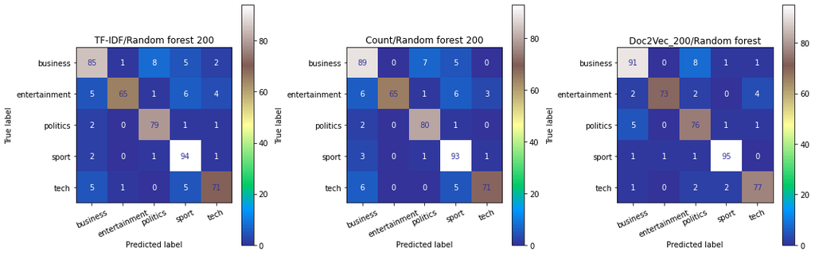

```python
titles = (f'TF-IDF/Random forest {VECTOR_LENGTH}',
          f'Count/Random forest {VECTOR_LENGTH}',
          f'Doc2Vec_{VECTOR_LENGTH}/Random forest')
models = (tfidf_clf_50, count_clf_50, doc2vec_50_clf)
test_x = (tfidf_vectors_test_50, count_vectors_test_50, doc2vec_50_vectors_test)
#import matplotlib.pyplot as plt
fig, axs = plt.subplots(1, 3, figsize=(15, 5))
axs = axs.flatten()
for cls, tst, axs, title in zip(models, test_x, axs, titles):
    plot_confusion_matrix(cls, tst, test_cat, ax=axs,
                          xticks_rotation=25, cmap='terrain')

    axs.set_title(title)
plt.tight_layout();
```

# 4.0 Clustering

```python
# kmeans functions


def print_top_terms(kmodel, x):    # x=number of top features to print
    print(f"Top {x} terms per cluster:")
    print()
    #sort cluster centers by proximity to centroid
    order_centroids = kmodel.cluster_centers_.argsort()[:, ::-1]

    for i in range(num_clusters):
        print("\nCluster %d:\n" % i, end='')

        for ind in order_centroids[i, :x]: #replace 6 with n words per cluster
            print('%s' % vocab_frame.loc[terms[ind].split(' ')].values.tolist()[0][0], end=', ')
        print('\n')
        print(f'Terms: {str(term_list.terms[term_list.cluster == i].tolist())}')
        print('\n')
        print(f'Example document: {terms[ind]} \n {bbc_all.text[bbc_all.idstr == terms[ind]].values}')
        print('\n')


def print_top_docs(kmodel, x):    # x=number of top features to print
    print("Top Docs per cluster:")
    #sort cluster centers by proximity to centroid
    order_centroids = kmodel.cluster_centers_.argsort()[:, ::-1]

    for i in range(num_clusters):
        print("\nCluster %d Terms:\n" % i, end='')

        for ind in order_centroids[i, :x]: #replace 6 with n words per cluster
            print('%s' % vocab_frame.loc[terms[ind].split(' ')].values.tolist()[0][0], end=', ')
        print('\n')
        doc = term_list.terms[term_list.cluster == i]
        doc = doc.reset_index(drop=True)
        #print(doc)
        print(f'Docs: {term_list.terms[term_list.cluster == i].iloc[:5].tolist()}')
        #print(f'Example terms: {terms[ind]} \n {bbc_all.text[bbc_all.idstr == terms[ind]].values}')
        print('\n')
        print(f'Example Text:  {doc.loc[0]} \n {bbc_all.text[bbc_all.idstr == doc.iloc[0]].iloc[0]}')
        #print(f'sdfds {bbc_all.text[bbc_all.idstr == doc.iloc[0]].iloc[0]}')
        print('\n')


# # Function to vizualize clusters
# def cluster_viz(df, clusters, features, pt_label):
#     dist = 1 - cosine_similarity(df)

#     MDS()

#     # convert two components as we're plotting points in a two-dimensional plane
#     # "precomputed" because we provide a distance matrix
#     # we will also specify `random_state` so the plot is reproducible.
#     mds = MDS(n_components=2, dissimilarity="precomputed", random_state=1)

#     pos = mds.fit_transform(dist)  # shape (n_components, n_samples)

#     xs, ys = pos[:, 0], pos[:, 1]

#     # some ipython magic to show the matplotlib plots inline
#     %matplotlib inline

#     # create data frame that has the result of the MDS plus the cluster numbers and titles
#     df = pd.DataFrame(dict(x=xs, y=ys, label=clusters, title=features))

#     # group by cluster
#     groups = df.groupby('label')

#     # set up plot
#     fig, ax = plt.subplots(figsize=(17, 9)) # set size
#     ax.margins(0.05) # Optional, just adds 5% padding to the autoscaling

#     #iterate through groups to layer the plot
#     #note that I use the cluster_name and cluster_color dicts with the 'name' lookup to return the appropriate color/label
#     for name, group in groups:
#         ax.plot(group.x, group.y, marker='o', linestyle='', ms=12, alpha=.5,
#                 label=cluster_names[name], color=cluster_colors[name],
#                 mec='none')
#         ax.set_aspect('auto')
#         ax.tick_params(\
#             axis= 'x',         # changes apply to the x-axis
#             which='both',      # both major and minor ticks are affected
#             bottom='off',      # ticks along the bottom edge are off
#             top='off',         # ticks along the top edge are off
#             labelbottom='off')
#         ax.tick_params(\
#             axis= 'y',         # changes apply to the y-axis
#             which='both',      # both major and minor ticks are affected
#             left='off',        # ticks along the bottom edge are off
#             top='off',         # ticks along the top edge are off
#             labelleft='off')

#     ax.legend(numpoints=1)  # show legend with only 1 point

#     if pt_label:
#       # add label in x,y position with the label as the film title
#       for i in range(len(df)):
#           ax.text(df.loc[i]['x'], df.loc[i]['y'], df.loc[i]['title'], size=8)

#     plt.show() #show the plot


def graph_tsne(df, pt_txt=False, rand_prob=0.2):
  standardized_data = StandardScaler().fit_transform(df)
  data_1000 = standardized_data
  labels_1000 = clusters
  titles = df.index.values.tolist()

  %matplotlib inline

  model = TSNE(n_components=2, random_state=SET_RANDOM)

  tsne_data = model.fit_transform(data_1000)
  tsne_data = np.vstack((tsne_data.T, labels_1000)).T
  tsne_df = pd.DataFrame(dict(Dim_1=tsne_data[:,0], Dim_2=tsne_data[:,1],
                              label=tsne_data[:,2].astype(int), titles=titles))

  # group by cluster
  groups = tsne_df.groupby('label')

  fig, ax = plt.subplots(figsize=(17, 9)) # set size
  ax.margins(0.05) # Optional, just adds 5% padding to the autoscaling

  for name, group in groups:
    ax.plot(group.Dim_1, group.Dim_2, marker='o', linestyle='', ms=12, alpha=.5,
            label=cluster_names[name], color=cluster_colors[name], mec='none')
    ax.set_aspect('auto')
    ax.tick_params(\
        axis= 'x',         # changes apply to the x-axis
        which='both',      # both major and minor ticks are affected
        bottom='off',      # ticks along the bottom edge are off
        top='off',         # ticks along the top edge are off
        labelbottom='off')
    ax.tick_params(\
        axis= 'y',         # changes apply to the y-axis
        which='both',      # both major and minor ticks are affected
        left='off',        # ticks along the bottom edge are off
        top='off',         # ticks along the top edge are off
        labelleft='off')

  ax.legend(numpoints=1)  # show legend with only 1 point
  if pt_txt:
    for i in range(len(tsne_df)):
      if random.random() < rand_prob:
        ax.text(tsne_df.loc[i]['Dim_1'], tsne_df.loc[i]['Dim_2'], tsne_df.loc[i]['titles'], size=8)

  plt.show()
  return data_1000
```

## 4.1 Count Vectorizer

```python
count_vectors = count_vectorizer.transform(bbc_all.text)
print('\ncount vectorization. . .' + str(VECTOR_LENGTH))
print('\nTraining count_vectors_training.shape:', count_vectors.shape)
```

```
count vectorization. . .200

Training count_vectors_training.shape: (2225, 200)
```

```python
# Create dataFrame
df_count = pd.DataFrame(count_vectors.toarray().transpose(),
                        index=count_vectorizer.get_feature_names())

# Change column headers
df_count.columns = bbc_all.idstr
df_count.head(50)
```

| idstr | tech_0 | busin_1 | sport_2 | sport_3 | enter_4 | polit_5 | polit_6 | sport_7 | sport_8 | enter_9 | ... | tech_2215 | enter_2216 | tech_2217 | sport_2218 | busin_2219 | busin_2220 | polit_2221 | enter_2222 | polit_2223 | sport_2224 |
| --- | --- | --- | --- | --- | --- | --- | --- | --- | --- | --- | --- | --- | --- | --- | --- | --- | --- | --- | --- | --- | --- |
| according | 1 | 0 | 0 | 0 | 1 | 0 | 0 | 0 | 0 | 0 | ... | 2 | 0 | 0 | 0 | 0 | 0 | 0 | 0 | 0 | 0 |
| action | 0 | 0 | 0 | 0 | 0 | 0 | 0 | 0 | 0 | 0 | ... | 0 | 0 | 0 | 0 | 0 | 0 | 0 | 0 | 0 | 0 |
| added | 1 | 0 | 0 | 0 | 0 | 0 | 0 | 0 | 0 | 0 | ... | 0 | 1 | 1 | 0 | 0 | 1 | 0 | 0 | 0 | 1 |
| already | 1 | 1 | 0 | 1 | 0 | 0 | 0 | 0 | 0 | 0 | ... | 0 | 0 | 0 | 0 | 0 | 0 | 0 | 0 | 0 | 0 |
| also | 3 | 0 | 0 | 0 | 0 | 2 | 1 | 0 | 0 | 0 | ... | 1 | 2 | 2 | 0 | 2 | 0 | 0 | 1 | 0 | 1 |
| another | 0 | 0 | 1 | 0 | 0 | 0 | 0 | 0 | 0 | 0 | ... | 0 | 0 | 1 | 0 | 0 | 0 | 0 | 0 | 0 | 0 |
| around | 0 | 0 | 0 | 0 | 0 | 0 | 0 | 0 | 0 | 0 | ... | 0 | 0 | 0 | 0 | 0 | 0 | 0 | 0 | 0 | 0 |
| awards | 0 | 0 | 0 | 0 | 0 | 0 | 0 | 0 | 0 | 0 | ... | 0 | 0 | 0 | 0 | 0 | 0 | 0 | 0 | 0 | 0 |
| away | 0 | 0 | 1 | 3 | 0 | 0 | 0 | 0 | 0 | 0 | ... | 0 | 0 | 0 | 0 | 0 | 0 | 0 | 0 | 0 | 0 |
| back | 0 | 0 | 1 | 0 | 0 | 2 | 1 | 1 | 0 | 0 | ... | 0 | 0 | 1 | 0 | 0 | 0 | 0 | 1 | 0 | 0 |
| bank | 0 | 0 | 0 | 0 | 0 | 0 | 0 | 0 | 0 | 0 | ... | 0 | 0 | 0 | 0 | 0 | 0 | 0 | 0 | 0 | 0 |
| bbc | 3 | 0 | 1 | 0 | 0 | 1 | 1 | 0 | 0 | 0 | ... | 0 | 0 | 0 | 1 | 0 | 0 | 0 | 0 | 0 | 0 |
| best | 0 | 0 | 0 | 0 | 0 | 0 | 0 | 0 | 0 | 0 | ... | 0 | 0 | 0 | 0 | 0 | 0 | 0 | 0 | 2 | 0 |
| better | 0 | 0 | 1 | 0 | 0 | 2 | 0 | 0 | 0 | 0 | ... | 0 | 1 | 0 | 0 | 0 | 0 | 0 | 0 | 4 | 0 |
| big | 1 | 0 | 2 | 0 | 0 | 0 | 0 | 0 | 0 | 0 | ... | 0 | 0 | 0 | 0 | 0 | 0 | 0 | 0 | 0 | 0 |
| blair | 0 | 0 | 0 | 0 | 0 | 1 | 5 | 0 | 0 | 0 | ... | 0 | 0 | 0 | 0 | 0 | 0 | 0 | 0 | 3 | 0 |
| britain | 0 | 0 | 1 | 0 | 0 | 1 | 0 | 0 | 0 | 0 | ... | 0 | 0 | 0 | 0 | 0 | 0 | 3 | 0 | 0 | 0 |
| british | 0 | 0 | 0 | 0 | 0 | 0 | 0 | 1 | 0 | 1 | ... | 0 | 0 | 0 | 0 | 0 | 0 | 0 | 0 | 0 | 0 |
| brown | 0 | 0 | 0 | 0 | 0 | 1 | 0 | 0 | 0 | 0 | ... | 0 | 0 | 0 | 0 | 0 | 0 | 0 | 0 | 3 | 0 |
| business | 1 | 0 | 0 | 0 | 0 | 0 | 1 | 0 | 0 | 0 | ... | 0 | 0 | 0 | 0 | 0 | 0 | 0 | 0 | 0 | 0 |
| called | 1 | 0 | 0 | 0 | 0 | 1 | 1 | 0 | 0 | 0 | ... | 0 | 0 | 1 | 0 | 0 | 0 | 0 | 0 | 0 | 0 |
| came | 0 | 0 | 0 | 0 | 0 | 0 | 0 | 0 | 0 | 0 | ... | 0 | 0 | 0 | 0 | 0 | 0 | 0 | 0 | 0 | 0 |
| campaign | 0 | 0 | 0 | 0 | 0 | 0 | 0 | 0 | 0 | 0 | ... | 0 | 0 | 0 | 0 | 0 | 0 | 0 | 0 | 0 | 0 |
| chief | 1 | 1 | 0 | 0 | 0 | 0 | 0 | 0 | 0 | 0 | ... | 0 | 0 | 1 | 0 | 0 | 2 | 0 | 0 | 0 | 0 |
| club | 0 | 0 | 1 | 0 | 0 | 0 | 0 | 0 | 0 | 0 | ... | 0 | 0 | 0 | 0 | 0 | 0 | 0 | 0 | 0 | 1 |
| come | 0 | 0 | 0 | 0 | 0 | 1 | 0 | 1 | 0 | 0 | ... | 0 | 0 | 0 | 0 | 0 | 0 | 0 | 0 | 1 | 0 |
| companies | 3 | 0 | 0 | 0 | 0 | 0 | 0 | 0 | 0 | 0 | ... | 0 | 0 | 0 | 0 | 0 | 0 | 0 | 0 | 0 | 0 |
| company | 0 | 1 | 0 | 0 | 0 | 0 | 0 | 0 | 0 | 0 | ... | 0 | 0 | 0 | 0 | 0 | 0 | 0 | 0 | 0 | 0 |
| computer | 0 | 0 | 0 | 0 | 0 | 0 | 0 | 0 | 0 | 0 | ... | 0 | 0 | 0 | 0 | 0 | 0 | 0 | 0 | 0 | 0 |
| could | 1 | 0 | 1 | 0 | 0 | 0 | 0 | 0 | 0 | 0 | ... | 0 | 0 | 1 | 0 | 0 | 0 | 0 | 0 | 0 | 0 |
| country | 0 | 0 | 0 | 0 | 0 | 4 | 0 | 0 | 0 | 0 | ... | 0 | 1 | 1 | 0 | 0 | 0 | 0 | 1 | 0 | 0 |
| court | 0 | 0 | 0 | 0 | 0 | 0 | 0 | 0 | 0 | 0 | ... | 0 | 0 | 0 | 0 | 0 | 0 | 0 | 0 | 0 | 0 |
| cup | 0 | 0 | 0 | 4 | 0 | 0 | 0 | 0 | 2 | 0 | ... | 0 | 0 | 0 | 0 | 0 | 0 | 0 | 0 | 0 | 2 |
| data | 0 | 0 | 0 | 0 | 0 | 0 | 0 | 0 | 0 | 0 | ... | 0 | 0 | 9 | 0 | 0 | 0 | 0 | 0 | 0 | 0 |
| day | 0 | 0 | 0 | 0 | 0 | 1 | 2 | 1 | 0 | 0 | ... | 0 | 0 | 0 | 0 | 0 | 0 | 0 | 0 | 0 | 0 |
| deal | 0 | 0 | 0 | 0 | 0 | 0 | 0 | 0 | 0 | 0 | ... | 0 | 0 | 0 | 1 | 0 | 0 | 0 | 0 | 0 | 0 |
| decision | 0 | 1 | 0 | 0 | 0 | 0 | 0 | 0 | 0 | 0 | ... | 0 | 0 | 0 | 0 | 0 | 0 | 0 | 0 | 1 | 1 |
| despite | 0 | 0 | 0 | 0 | 0 | 0 | 0 | 0 | 0 | 0 | ... | 0 | 0 | 0 | 1 | 0 | 0 | 0 | 0 | 0 | 0 |
| digital | 2 | 0 | 0 | 0 | 0 | 0 | 0 | 0 | 0 | 0 | ... | 0 | 0 | 0 | 0 | 0 | 0 | 0 | 0 | 0 | 0 |
| director | 0 | 0 | 0 | 0 | 1 | 0 | 0 | 0 | 1 | 0 | ... | 1 | 0 | 0 | 0 | 0 | 0 | 0 | 1 | 0 | 0 |
| economic | 0 | 0 | 0 | 0 | 0 | 0 | 0 | 0 | 0 | 0 | ... | 0 | 0 | 0 | 0 | 0 | 0 | 0 | 0 | 1 | 0 |
| economy | 0 | 0 | 0 | 0 | 0 | 0 | 0 | 0 | 0 | 0 | ... | 0 | 0 | 0 | 0 | 0 | 0 | 0 | 0 | 0 | 0 |
| election | 0 | 0 | 0 | 0 | 0 | 5 | 6 | 0 | 0 | 0 | ... | 0 | 0 | 0 | 0 | 0 | 0 | 0 | 0 | 0 | 0 |
| end | 1 | 0 | 0 | 1 | 0 | 0 | 2 | 1 | 0 | 0 | ... | 0 | 0 | 0 | 0 | 0 | 0 | 0 | 0 | 2 | 1 |
| england | 0 | 0 | 1 | 0 | 0 | 0 | 0 | 0 | 3 | 0 | ... | 0 | 0 | 0 | 1 | 0 | 0 | 0 | 0 | 0 | 0 |
| europe | 2 | 0 | 0 | 0 | 1 | 0 | 0 | 0 | 0 | 0 | ... | 0 | 0 | 0 | 0 | 0 | 0 | 0 | 1 | 0 | 0 |
| european | 0 | 0 | 0 | 0 | 0 | 0 | 0 | 0 | 0 | 0 | ... | 0 | 0 | 0 | 0 | 0 | 0 | 0 | 0 | 0 | 0 |
| even | 1 | 0 | 0 | 0 | 0 | 1 | 0 | 0 | 0 | 0 | ... | 0 | 0 | 0 | 0 | 0 | 0 | 0 | 0 | 4 | 0 |
| every | 0 | 0 | 0 | 0 | 0 | 0 | 0 | 0 | 0 | 0 | ... | 0 | 0 | 1 | 0 | 0 | 0 | 0 | 0 | 1 | 0 |
| executive | 0 | 0 | 0 | 0 | 0 | 0 | 0 | 0 | 0 | 0 | ... | 0 | 0 | 0 | 0 | 0 | 0 | 0 | 0 | 0 | 0 |

50 rows × 2225 columns

```python
df_count.describe()
```

| idstr | tech_0 | busin_1 | sport_2 | sport_3 | enter_4 | polit_5 | polit_6 | sport_7 | sport_8 | enter_9 | ... | tech_2215 | enter_2216 | tech_2217 | sport_2218 | busin_2219 | busin_2220 | polit_2221 | enter_2222 | polit_2223 | sport_2224 |
| --- | --- | --- | --- | --- | --- | --- | --- | --- | --- | --- | --- | --- | --- | --- | --- | --- | --- | --- | --- | --- | --- |
| count | 200.000000 | 200.00000 | 200.000000 | 200.000000 | 200.000000 | 200.00000 | 200.000000 | 200.000000 | 200.000000 | 200.000000 | ... | 200.000000 | 200.00000 | 200.000000 | 200.00000 | 200.000000 | 200.000000 | 200.000000 | 200.000000 | 200.000000 | 200.000000 |
| mean | 0.490000 | 0.12500 | 0.195000 | 0.140000 | 0.165000 | 0.51000 | 0.225000 | 0.110000 | 0.105000 | 0.160000 | ... | 0.130000 | 0.20500 | 0.515000 | 0.16500 | 0.145000 | 0.210000 | 0.100000 | 0.140000 | 0.350000 | 0.210000 |
| std | 1.046603 | 0.42459 | 0.477614 | 0.576247 | 0.467835 | 1.45274 | 0.732844 | 0.329306 | 0.380393 | 0.588329 | ... | 0.462786 | 0.54263 | 1.644169 | 0.50899 | 0.515074 | 1.163041 | 0.480787 | 0.425801 | 1.001255 | 0.581023 |
| min | 0.000000 | 0.00000 | 0.000000 | 0.000000 | 0.000000 | 0.00000 | 0.000000 | 0.000000 | 0.000000 | 0.000000 | ... | 0.000000 | 0.00000 | 0.000000 | 0.00000 | 0.000000 | 0.000000 | 0.000000 | 0.000000 | 0.000000 | 0.000000 |
| 25% | 0.000000 | 0.00000 | 0.000000 | 0.000000 | 0.000000 | 0.00000 | 0.000000 | 0.000000 | 0.000000 | 0.000000 | ... | 0.000000 | 0.00000 | 0.000000 | 0.00000 | 0.000000 | 0.000000 | 0.000000 | 0.000000 | 0.000000 | 0.000000 |
| 50% | 0.000000 | 0.00000 | 0.000000 | 0.000000 | 0.000000 | 0.00000 | 0.000000 | 0.000000 | 0.000000 | 0.000000 | ... | 0.000000 | 0.00000 | 0.000000 | 0.00000 | 0.000000 | 0.000000 | 0.000000 | 0.000000 | 0.000000 | 0.000000 |
| 75% | 1.000000 | 0.00000 | 0.000000 | 0.000000 | 0.000000 | 1.00000 | 0.000000 | 0.000000 | 0.000000 | 0.000000 | ... | 0.000000 | 0.00000 | 0.000000 | 0.00000 | 0.000000 | 0.000000 | 0.000000 | 0.000000 | 0.000000 | 0.000000 |
| max | 7.000000 | 3.00000 | 2.000000 | 4.000000 | 3.000000 | 14.00000 | 6.000000 | 2.000000 | 3.000000 | 4.000000 | ... | 4.000000 | 4.00000 | 17.000000 | 4.00000 | 3.000000 | 15.000000 | 5.000000 | 3.000000 | 9.000000 | 3.000000 |

8 rows × 2225 columns

### 4.1.a Terms as objects

```python
# Kmeans
num_clusters = 5

km_ct = KMeans(n_clusters=num_clusters, random_state=SET_RANDOM)
#km_ct = KMeans(random_state=SET_RANDOM)

%time km_ct.fit(df_count)

clusters = km_ct.labels_.tolist()
```

```
Wall time: 500 ms
```

```python
num_clusters = len(set(clusters))
print(f'Clusters: \n {Counter(clusters).keys()}')
print(f'Terms per cluster: \n {Counter(clusters).values()}')
```

```
Clusters:
 dict_keys([1, 0, 3, 4, 2])
Terms per cluster:
 dict_values([185, 9, 3, 2, 1])
```

Per table below, Cluster 1 contains 185 terms but the other 4 clusters combined contain only 15 terms.

```python
term_list = pd.DataFrame({'terms':df_count.index.values.tolist(), 'cluster':clusters})
term_list.groupby('cluster').count()
```

| cluster | terms |
| --- | --- |
| 0 | 9 |
| 1 | 185 |
| 2 | 1 |
| 3 | 3 |
| 4 | 2 |

```python
# save pkl
joblib.dump(km_ct, 'doc_cluster_count_1.pkl')

km_ct = joblib.load('doc_cluster_count_1.pkl')
clusters = km_ct.labels_.tolist()

terms = df_count.columns
vocab_frame = pd.DataFrame({'docs': df_count.columns}, index=terms)
```

```python
print_top_terms(km_ct, 5)
```

```
Top 5 terms per cluster:


Cluster 0:
enter_1615, enter_865, polit_408, enter_880, polit_677,

Terms: ['also', 'best', 'like', 'music', 'new', 'one', 'people', 'would', 'years']


Example document: polit_677
 ['minimum wage increased minimum wage rise october benefiting people government announced adults must paid least hour year olds paid recommendations came low pay commission said number jobs continued grow since minimum wage introduced businesses wanted frozen warning rises could damage competitiven…



Cluster 1:
polit_408, polit_677, enter_1615, tech_482, polit_1604,

Terms: ['according', 'action', 'added', 'already', 'another', 'around', 'awards', 'away', 'back', 'bank', 'bbc', 'better', 'big', 'blair', 'britain', 'british', 'brown', 'business', 'called', 'came', 'campaign', 'chief', 'club', 'come', 'companies', 'company', 'computer', 'could', 'country', 'court'…


Example document: polit_1604
 ['kilroy launches veritas party exbbc chat show host east midlands mep robert kilroysilk said wanted change face british politics launched new party mr kilroysilk recently quit uk independence party said country stolen us mass immigration told london news conference veritas latin truth would avoid …



Cluster 2:
tech_142, tech_644, tech_839, tech_2217, tech_1021,

Terms: ['said']


Example document: tech_1021
 ['format wars could confuse users technology firms sony philips matsushita samsung developing common way stop people pirating digital music video firms want make system ensures files play hardware make also thwarts illegal copying move could mean confusion consumers already faced many different con…



Cluster 3:
polit_1604, polit_1545, polit_1508, polit_161, polit_530,

Terms: ['election', 'labour', 'party']


Example document: polit_530
 ['labour core support takes stock tony blair told labour supporters back still hungry job prime minister sum mood party spring conference gateshead electorate keener government labour party members dry assessment graham lane leader labour group newham council problem according mr lane continuing di…



Cluster 4:
tech_482, tech_351, tech_624, tech_1441, tech_2085,

Terms: ['game', 'games']


Example document: tech_2085
 ['mobile games come age bbc news website takes look games mobile phones maturing brief roundup follows skip straight reviews clicking links think snake mentions mobile games could bit surprise mobile games come long way short time even nokia ngage game phone launched late many mobile operators real…
```

```python
#set up colors per clusters using a dict
cluster_colors = {0: '#1b9e77', 1: '#d95f02', 2: '#7570b3', 3: '#e7298a', 4: '#66a61e'}

#set up cluster names using a dict
cluster_names = {0: 'c0',
                 1: 'c1',
                 2: 'c2',
                 3: 'c3',
                 4: 'c4'}
```

```python
# cluster_viz(df_count, clusters, df_count.index.values.tolist(), True)
```

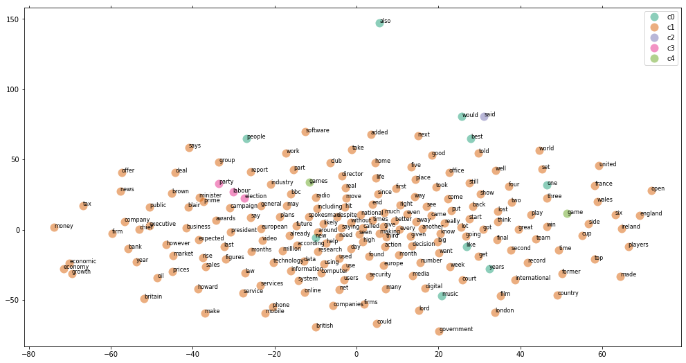

```python
tsne_data = graph_tsne(df_count, True, 1)
```

### Hierarchical document clustering

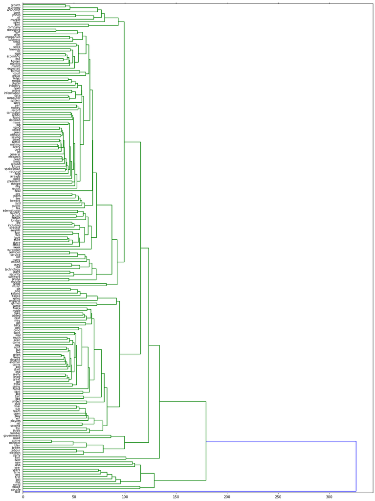

```python
linkage_matrix = ward(tsne_data) #define the linkage_matrix using ward clustering pre-computed distances

fig, ax = plt.subplots(figsize=(15, 20)) # set size
ax = dendrogram(linkage_matrix, orientation="right",
                labels=df_count.index.values.tolist(),
                leaf_font_size=8);

plt.tick_params(\
    axis= 'x',          # changes apply to the x-axis
    which='both',      # both major and minor ticks are affected
    bottom='off',      # ticks along the bottom edge are off
    top='off',         # ticks along the top edge are off
    labelbottom='off')

plt.tight_layout() #show plot with tight layout

#uncomment below to save figure
#plt.savefig('ward_clusters.png', dpi=200) #save figure as ward_clusters
```

### 4.1.b Docs as objects

```python
df_count.T.head()
```

| idstr | according | action | added | already | also | another | around | awards | away | back | ... | way | week | well | win | without | work | world | would | year | years |
| --- | --- | --- | --- | --- | --- | --- | --- | --- | --- | --- | --- | --- | --- | --- | --- | --- | --- | --- | --- | --- | --- |
| tech_0 | 1 | 0 | 1 | 1 | 3 | 0 | 0 | 0 | 0 | 0 | ... | 2 | 0 | 1 | 0 | 0 | 1 | 0 | 0 | 0 | 2 |
| busin_1 | 0 | 0 | 0 | 1 | 0 | 0 | 0 | 0 | 0 | 0 | ... | 0 | 0 | 0 | 0 | 0 | 0 | 0 | 0 | 0 | 0 |
| sport_2 | 0 | 0 | 0 | 0 | 0 | 1 | 0 | 0 | 1 | 1 | ... | 1 | 0 | 0 | 0 | 0 | 0 | 0 | 2 | 0 | 0 |
| sport_3 | 0 | 0 | 0 | 1 | 0 | 0 | 0 | 0 | 3 | 0 | ... | 0 | 0 | 0 | 1 | 0 | 0 | 0 | 0 | 0 | 0 |
| enter_4 | 1 | 0 | 0 | 0 | 0 | 0 | 0 | 0 | 0 | 0 | ... | 0 | 1 | 0 | 0 | 0 | 0 | 0 | 0 | 0 | 0 |

5 rows × 200 columns

```python
# Kmeans
num_clusters = 5

km_ct = KMeans(n_clusters=num_clusters, random_state=SET_RANDOM)
#km_ct = KMeans(random_state=SET_RANDOM)

%time km_ct.fit(df_count.T)

clusters = km_ct.labels_.tolist()
```

```
Wall time: 1.12 s
```

```python
num_clusters = len(set(clusters))
print(f'Clusters: \n {Counter(clusters).keys()}')
print(f'Terms per cluster: \n {Counter(clusters).values()}')
```

```
Clusters:
 dict_keys([0, 4, 1, 2, 3])
Terms per cluster:
 dict_values([161, 1376, 130, 554, 4])
```

Clustering with Terms as features leads to a better spread of documents across clusters:

```python
term_list = pd.DataFrame({'terms':df_count.T.index.values.tolist(), 'cluster':clusters})
term_list.groupby('cluster').count().rename(columns={'terms':'docs'})
```

| cluster | docs |
| --- | --- |
| 0 | 161 |
| 1 | 130 |
| 2 | 554 |
| 3 | 4 |
| 4 | 1376 |

```python
# save pkl
joblib.dump(km_ct, 'doc_cluster_count_2.pkl')

km_ct = joblib.load('doc_cluster_count_2.pkl')
clusters = km_ct.labels_.tolist()

terms = df_count.T.columns
vocab_frame = pd.DataFrame({'docs': df_count.T.columns}, index=terms)
```

```python
print_top_docs(km_ct, 5)
```

```
Top Docs per cluster:

Cluster 0 Terms:
said, people, music, mobile, technology,

Docs: ['tech_0', 'tech_24', 'tech_27', 'enter_45', 'tech_65']


Example Text:  tech_0
 tv future hands viewers home theatre systems plasma highdefinition tvs digital video recorders moving living room way people watch tv radically different five years time according expert panel gathered annual consumer electronics show las vegas discuss new technologies impact one favourite pastimes…



Cluster 1 Terms:
said, labour, would, election, party,

Docs: ['polit_5', 'polit_47', 'polit_117', 'polit_161', 'polit_168']


Example Text:  polit_5
 howard hits back mongrel jibe michael howard said claim peter hain tory leader acting like attack mongrel shows labour rattled opposition upbeat speech party spring conference brighton said labour campaigning tactics proved tories hitting home mr hain made claim tory tactics antiterror bill debate …



Cluster 2 Terms:
said, would, new, people, also,

Docs: ['polit_13', 'sport_14', 'tech_19', 'tech_21', 'polit_28']


Example Text:  polit_13
 hague given pm ambition former conservative leader william hague says stand leadership given ambition prime minister mr hague told daily telegraph would find life dominated politics boring unfulfilling mr hague stepped party election defeat rule return front bench also told paper hopes remain mp ri…



Cluster 3 Terms:
music, people, best, years, government,

Docs: ['polit_408', 'polit_677', 'enter_865', 'enter_1615']


Example Text:  polit_408
 terror powers expose tyranny lord chancellor defended government plans introduce control orders keep foreign british terrorist suspects house arrest enough evidence put trial lord falconer insists proposals equate police state strike balance protecting public threat terrorism upholding civil libert…



Cluster 4 Terms:
said, year, also, one, last,

Docs: ['busin_1', 'sport_2', 'sport_3', 'enter_4', 'polit_6']


Example Text:  busin_1
 worldcom boss left books alone former worldcom boss bernie ebbers accused overseeing fraud never made accounting decisions witness told jurors david myers made comments questioning defence lawyers arguing mr ebbers responsible worldcom problems phone company collapsed prosecutors claim losses hidde…
```

Comparing Count vectorization of Documents compared to their actual labels shows that each class may be composed of 2-3 main clusters:

- Business - Clusters 2 and 4
- Entertainment - Clusters 4 and 2
- Politics - Clusters 1, 2, and 4
- Sport - Cluster 4
- Tech - Clusters 0, 2, and 4

```python
lab_clus = pd.DataFrame({'clusters':clusters, 'label':bbc_labels,
                         'text':bbc_text})
lab_clus.pivot_table(index='clusters', columns='label',
                     aggfunc=len, fill_value=0)
```

| label clusters | text business | text entertainment | text politics | text sport | text tech |
| --- | --- | --- | --- | --- | --- |
| 0 | 3 | 14 | 0 | 2 | 142 |
| 1 | 1 | 0 | 127 | 2 | 0 |
| 2 | 173 | 53 | 193 | 40 | 95 |
| 3 | 0 | 2 | 2 | 0 | 0 |
| 4 | 333 | 317 | 95 | 467 | 164 |

```python
#set up colors per clusters using a dict
cluster_colors = {0: '#1b9e77', 1: '#d95f02', 2: '#7570b3', 3: '#e7298a', 4: '#66a61e'}

#set up cluster names using a dict
cluster_names = {0: 'c0', # tech
                 1: 'c1', # pols
                 2: 'c2', # bus/pol
                 3: 'c3', # ?
                 4: 'c4'} # all
```

```python
# cluster_viz(df_count.T, clusters, df_count.columns.values.tolist(), False)
```

T-SNE graph of Clusters for Count Vectorization with Terms as features

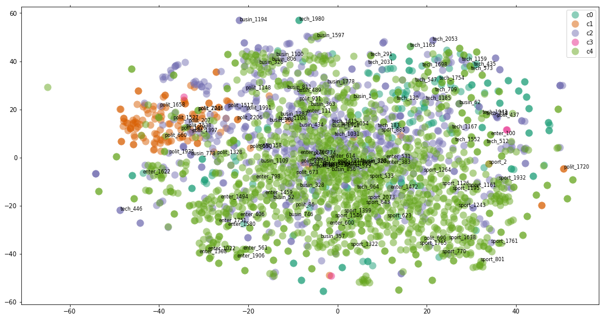

```python
_ = graph_tsne(df_count.T, True, 0.05)
```

## 4.2 TF-IDF Vectorizer matrix

### 4.2.a Terms as objects

```python
tfidf_vectors = tfidf_vectorizer.transform(bbc_all.text)
print('\nTFIDF vectorization. . .' + str(VECTOR_LENGTH))
print('\nTraining tfidf_vectors_training.shape:', tfidf_vectors.shape)
```

```
TFIDF vectorization. . .200

Training tfidf_vectors_training.shape: (2225, 200)
```

```python
# Create dataFrame
df_tfidf = pd.DataFrame(tfidf_vectors.toarray().transpose(),
                        index=tfidf_vectorizer.get_feature_names())

# Change column headers
df_tfidf.columns = bbc_all.idstr
df_tfidf.head(50)
```

| idstr | tech_0 | busin_1 | sport_2 | sport_3 | enter_4 | polit_5 | polit_6 | sport_7 | sport_8 | enter_9 | ... | tech_2215 | enter_2216 | tech_2217 | sport_2218 | busin_2219 | busin_2220 | polit_2221 | enter_2222 | polit_2223 | sport_2224 |
| --- | --- | --- | --- | --- | --- | --- | --- | --- | --- | --- | --- | --- | --- | --- | --- | --- | --- | --- | --- | --- | --- |
| according | 0.069864 | 0.000000 | 0.000000 | 0.000000 | 0.143700 | 0.000000 | 0.000000 | 0.000000 | 0.000000 | 0.000000 | ... | 0.305145 | 0.000000 | 0.000000 | 0.000000 | 0.000000 | 0.000000 | 0.000000 | 0.000000 | 0.000000 | 0.000000 |
| action | 0.000000 | 0.000000 | 0.000000 | 0.000000 | 0.000000 | 0.000000 | 0.000000 | 0.000000 | 0.000000 | 0.000000 | ... | 0.000000 | 0.000000 | 0.000000 | 0.000000 | 0.000000 | 0.000000 | 0.000000 | 0.000000 | 0.000000 | 0.000000 |
| added | 0.056654 | 0.000000 | 0.000000 | 0.000000 | 0.000000 | 0.000000 | 0.000000 | 0.000000 | 0.000000 | 0.000000 | ... | 0.000000 | 0.102652 | 0.039372 | 0.000000 | 0.000000 | 0.042984 | 0.000000 | 0.000000 | 0.000000 | 0.101946 |
| already | 0.066598 | 0.158635 | 0.000000 | 0.097845 | 0.000000 | 0.000000 | 0.000000 | 0.000000 | 0.000000 | 0.000000 | ... | 0.000000 | 0.000000 | 0.000000 | 0.000000 | 0.000000 | 0.000000 | 0.000000 | 0.000000 | 0.000000 | 0.000000 |
| also | 0.113296 | 0.000000 | 0.000000 | 0.000000 | 0.000000 | 0.045498 | 0.046447 | 0.000000 | 0.000000 | 0.000000 | ... | 0.082474 | 0.136853 | 0.052490 | 0.000000 | 0.162385 | 0.000000 | 0.000000 | 0.086855 | 0.000000 | 0.067957 |
| another | 0.000000 | 0.000000 | 0.152913 | 0.000000 | 0.000000 | 0.000000 | 0.000000 | 0.000000 | 0.000000 | 0.000000 | ... | 0.000000 | 0.000000 | 0.049779 | 0.000000 | 0.000000 | 0.000000 | 0.000000 | 0.000000 | 0.000000 | 0.000000 |
| around | 0.000000 | 0.000000 | 0.000000 | 0.000000 | 0.000000 | 0.000000 | 0.000000 | 0.000000 | 0.000000 | 0.000000 | ... | 0.000000 | 0.000000 | 0.000000 | 0.000000 | 0.000000 | 0.000000 | 0.000000 | 0.000000 | 0.000000 | 0.000000 |
| awards | 0.000000 | 0.000000 | 0.000000 | 0.000000 | 0.000000 | 0.000000 | 0.000000 | 0.000000 | 0.000000 | 0.000000 | ... | 0.000000 | 0.000000 | 0.000000 | 0.000000 | 0.000000 | 0.000000 | 0.000000 | 0.000000 | 0.000000 | 0.000000 |
| away | 0.000000 | 0.000000 | 0.161395 | 0.333226 | 0.000000 | 0.000000 | 0.000000 | 0.000000 | 0.000000 | 0.000000 | ... | 0.000000 | 0.000000 | 0.000000 | 0.000000 | 0.000000 | 0.000000 | 0.000000 | 0.000000 | 0.000000 | 0.000000 |
| back | 0.000000 | 0.000000 | 0.122749 | 0.000000 | 0.000000 | 0.069274 | 0.070719 | 0.179986 | 0.000000 | 0.000000 | ... | 0.000000 | 0.000000 | 0.039959 | 0.000000 | 0.000000 | 0.000000 | 0.000000 | 0.132242 | 0.000000 | 0.000000 |
| bank | 0.000000 | 0.000000 | 0.000000 | 0.000000 | 0.000000 | 0.000000 | 0.000000 | 0.000000 | 0.000000 | 0.000000 | ... | 0.000000 | 0.000000 | 0.000000 | 0.000000 | 0.000000 | 0.000000 | 0.000000 | 0.000000 | 0.000000 | 0.000000 |
| bbc | 0.182519 | 0.000000 | 0.129878 | 0.000000 | 0.000000 | 0.036649 | 0.074826 | 0.000000 | 0.000000 | 0.000000 | ... | 0.000000 | 0.000000 | 0.000000 | 0.111562 | 0.000000 | 0.000000 | 0.000000 | 0.000000 | 0.000000 | 0.000000 |
| best | 0.000000 | 0.000000 | 0.000000 | 0.000000 | 0.000000 | 0.000000 | 0.000000 | 0.000000 | 0.000000 | 0.000000 | ... | 0.000000 | 0.000000 | 0.000000 | 0.000000 | 0.000000 | 0.000000 | 0.000000 | 0.000000 | 0.153931 | 0.000000 |
| better | 0.000000 | 0.000000 | 0.157203 | 0.000000 | 0.000000 | 0.088718 | 0.000000 | 0.000000 | 0.000000 | 0.000000 | ... | 0.000000 | 0.133427 | 0.000000 | 0.000000 | 0.000000 | 0.000000 | 0.000000 | 0.000000 | 0.330695 | 0.000000 |
| big | 0.072614 | 0.000000 | 0.310027 | 0.000000 | 0.000000 | 0.000000 | 0.000000 | 0.000000 | 0.000000 | 0.000000 | ... | 0.000000 | 0.000000 | 0.000000 | 0.000000 | 0.000000 | 0.000000 | 0.000000 | 0.000000 | 0.000000 | 0.000000 |
| blair | 0.000000 | 0.000000 | 0.000000 | 0.000000 | 0.000000 | 0.051660 | 0.527380 | 0.000000 | 0.000000 | 0.000000 | ... | 0.000000 | 0.000000 | 0.000000 | 0.000000 | 0.000000 | 0.000000 | 0.000000 | 0.000000 | 0.288844 | 0.000000 |
| britain | 0.000000 | 0.000000 | 0.163122 | 0.000000 | 0.000000 | 0.046029 | 0.000000 | 0.000000 | 0.000000 | 0.000000 | ... | 0.000000 | 0.000000 | 0.000000 | 0.000000 | 0.000000 | 0.000000 | 0.637996 | 0.000000 | 0.000000 | 0.000000 |
| british | 0.000000 | 0.000000 | 0.000000 | 0.000000 | 0.000000 | 0.000000 | 0.000000 | 0.226982 | 0.000000 | 0.142282 | ... | 0.000000 | 0.000000 | 0.000000 | 0.000000 | 0.000000 | 0.000000 | 0.000000 | 0.000000 | 0.000000 | 0.000000 |
| brown | 0.000000 | 0.000000 | 0.000000 | 0.000000 | 0.000000 | 0.056135 | 0.000000 | 0.000000 | 0.000000 | 0.000000 | ... | 0.000000 | 0.000000 | 0.000000 | 0.000000 | 0.000000 | 0.000000 | 0.000000 | 0.000000 | 0.313863 | 0.000000 |
| business | 0.076178 | 0.000000 | 0.000000 | 0.000000 | 0.000000 | 0.000000 | 0.093691 | 0.000000 | 0.000000 | 0.000000 | ... | 0.000000 | 0.000000 | 0.000000 | 0.000000 | 0.000000 | 0.000000 | 0.000000 | 0.000000 | 0.000000 | 0.000000 |
| called | 0.075153 | 0.000000 | 0.000000 | 0.000000 | 0.000000 | 0.045271 | 0.092430 | 0.000000 | 0.000000 | 0.000000 | ... | 0.000000 | 0.000000 | 0.052227 | 0.000000 | 0.000000 | 0.000000 | 0.000000 | 0.000000 | 0.000000 | 0.000000 |
| came | 0.000000 | 0.000000 | 0.000000 | 0.000000 | 0.000000 | 0.000000 | 0.000000 | 0.000000 | 0.000000 | 0.000000 | ... | 0.000000 | 0.000000 | 0.000000 | 0.000000 | 0.000000 | 0.000000 | 0.000000 | 0.000000 | 0.000000 | 0.000000 |
| campaign | 0.000000 | 0.000000 | 0.000000 | 0.000000 | 0.000000 | 0.000000 | 0.000000 | 0.000000 | 0.000000 | 0.000000 | ... | 0.000000 | 0.000000 | 0.000000 | 0.000000 | 0.000000 | 0.000000 | 0.000000 | 0.000000 | 0.000000 | 0.000000 |
| chief | 0.069070 | 0.164523 | 0.000000 | 0.000000 | 0.000000 | 0.000000 | 0.000000 | 0.000000 | 0.000000 | 0.000000 | ... | 0.000000 | 0.000000 | 0.048000 | 0.000000 | 0.000000 | 0.104807 | 0.000000 | 0.000000 | 0.000000 | 0.000000 |
| club | 0.000000 | 0.000000 | 0.184576 | 0.000000 | 0.000000 | 0.000000 | 0.000000 | 0.000000 | 0.000000 | 0.000000 | ... | 0.000000 | 0.000000 | 0.000000 | 0.000000 | 0.000000 | 0.000000 | 0.000000 | 0.000000 | 0.000000 | 0.155583 |
| come | 0.000000 | 0.000000 | 0.000000 | 0.000000 | 0.000000 | 0.040893 | 0.000000 | 0.212493 | 0.000000 | 0.000000 | ... | 0.000000 | 0.000000 | 0.000000 | 0.000000 | 0.000000 | 0.000000 | 0.000000 | 0.000000 | 0.076213 | 0.000000 |
| companies | 0.230301 | 0.000000 | 0.000000 | 0.000000 | 0.000000 | 0.000000 | 0.000000 | 0.000000 | 0.000000 | 0.000000 | ... | 0.000000 | 0.000000 | 0.000000 | 0.000000 | 0.000000 | 0.000000 | 0.000000 | 0.000000 | 0.000000 | 0.000000 |
| company | 0.000000 | 0.157161 | 0.000000 | 0.000000 | 0.000000 | 0.000000 | 0.000000 | 0.000000 | 0.000000 | 0.000000 | ... | 0.000000 | 0.000000 | 0.000000 | 0.000000 | 0.000000 | 0.000000 | 0.000000 | 0.000000 | 0.000000 | 0.000000 |
| computer | 0.000000 | 0.000000 | 0.000000 | 0.000000 | 0.000000 | 0.000000 | 0.000000 | 0.000000 | 0.000000 | 0.000000 | ... | 0.000000 | 0.000000 | 0.000000 | 0.000000 | 0.000000 | 0.000000 | 0.000000 | 0.000000 | 0.000000 | 0.000000 |
| could | 0.046772 | 0.000000 | 0.099846 | 0.000000 | 0.000000 | 0.000000 | 0.000000 | 0.000000 | 0.000000 | 0.000000 | ... | 0.000000 | 0.000000 | 0.032504 | 0.000000 | 0.000000 | 0.000000 | 0.000000 | 0.000000 | 0.000000 | 0.000000 |
| country | 0.000000 | 0.000000 | 0.000000 | 0.000000 | 0.000000 | 0.168990 | 0.000000 | 0.000000 | 0.000000 | 0.000000 | ... | 0.000000 | 0.127076 | 0.048739 | 0.000000 | 0.000000 | 0.000000 | 0.000000 | 0.161299 | 0.000000 | 0.000000 |
| court | 0.000000 | 0.000000 | 0.000000 | 0.000000 | 0.000000 | 0.000000 | 0.000000 | 0.000000 | 0.000000 | 0.000000 | ... | 0.000000 | 0.000000 | 0.000000 | 0.000000 | 0.000000 | 0.000000 | 0.000000 | 0.000000 | 0.000000 | 0.000000 |
| cup | 0.000000 | 0.000000 | 0.000000 | 0.517853 | 0.000000 | 0.000000 | 0.000000 | 0.000000 | 0.437921 | 0.000000 | ... | 0.000000 | 0.000000 | 0.000000 | 0.000000 | 0.000000 | 0.000000 | 0.000000 | 0.000000 | 0.000000 | 0.317131 |
| data | 0.000000 | 0.000000 | 0.000000 | 0.000000 | 0.000000 | 0.000000 | 0.000000 | 0.000000 | 0.000000 | 0.000000 | ... | 0.000000 | 0.000000 | 0.559723 | 0.000000 | 0.000000 | 0.000000 | 0.000000 | 0.000000 | 0.000000 | 0.000000 |
| day | 0.000000 | 0.000000 | 0.000000 | 0.000000 | 0.000000 | 0.043681 | 0.178368 | 0.226982 | 0.000000 | 0.000000 | ... | 0.000000 | 0.000000 | 0.000000 | 0.000000 | 0.000000 | 0.000000 | 0.000000 | 0.000000 | 0.000000 | 0.000000 |
| deal | 0.000000 | 0.000000 | 0.000000 | 0.000000 | 0.000000 | 0.000000 | 0.000000 | 0.000000 | 0.000000 | 0.000000 | ... | 0.000000 | 0.000000 | 0.000000 | 0.142780 | 0.000000 | 0.000000 | 0.000000 | 0.000000 | 0.000000 | 0.000000 |
| decision | 0.000000 | 0.184880 | 0.000000 | 0.000000 | 0.000000 | 0.000000 | 0.000000 | 0.000000 | 0.000000 | 0.000000 | ... | 0.000000 | 0.000000 | 0.000000 | 0.000000 | 0.000000 | 0.000000 | 0.000000 | 0.000000 | 0.087138 | 0.139666 |
| despite | 0.000000 | 0.000000 | 0.000000 | 0.000000 | 0.000000 | 0.000000 | 0.000000 | 0.000000 | 0.000000 | 0.000000 | ... | 0.000000 | 0.000000 | 0.000000 | 0.134083 | 0.000000 | 0.000000 | 0.000000 | 0.000000 | 0.000000 | 0.000000 |
| digital | 0.175858 | 0.000000 | 0.000000 | 0.000000 | 0.000000 | 0.000000 | 0.000000 | 0.000000 | 0.000000 | 0.000000 | ... | 0.000000 | 0.000000 | 0.000000 | 0.000000 | 0.000000 | 0.000000 | 0.000000 | 0.000000 | 0.000000 | 0.000000 |
| director | 0.000000 | 0.000000 | 0.000000 | 0.000000 | 0.151251 | 0.000000 | 0.000000 | 0.000000 | 0.182722 | 0.000000 | ... | 0.160590 | 0.000000 | 0.000000 | 0.000000 | 0.000000 | 0.000000 | 0.000000 | 0.169121 | 0.000000 | 0.000000 |
| economic | 0.000000 | 0.000000 | 0.000000 | 0.000000 | 0.000000 | 0.000000 | 0.000000 | 0.000000 | 0.000000 | 0.000000 | ... | 0.000000 | 0.000000 | 0.000000 | 0.000000 | 0.000000 | 0.000000 | 0.000000 | 0.000000 | 0.093868 | 0.000000 |
| economy | 0.000000 | 0.000000 | 0.000000 | 0.000000 | 0.000000 | 0.000000 | 0.000000 | 0.000000 | 0.000000 | 0.000000 | ... | 0.000000 | 0.000000 | 0.000000 | 0.000000 | 0.000000 | 0.000000 | 0.000000 | 0.000000 | 0.000000 | 0.000000 |
| election | 0.000000 | 0.000000 | 0.000000 | 0.000000 | 0.000000 | 0.246768 | 0.604596 | 0.000000 | 0.000000 | 0.000000 | ... | 0.000000 | 0.000000 | 0.000000 | 0.000000 | 0.000000 | 0.000000 | 0.000000 | 0.000000 | 0.000000 | 0.000000 |
| end | 0.066056 | 0.000000 | 0.000000 | 0.097049 | 0.000000 | 0.000000 | 0.162484 | 0.206768 | 0.000000 | 0.000000 | ... | 0.000000 | 0.000000 | 0.000000 | 0.000000 | 0.000000 | 0.000000 | 0.000000 | 0.000000 | 0.148320 | 0.118864 |
| england | 0.000000 | 0.000000 | 0.165957 | 0.000000 | 0.000000 | 0.000000 | 0.000000 | 0.000000 | 0.579514 | 0.000000 | ... | 0.000000 | 0.000000 | 0.000000 | 0.142552 | 0.000000 | 0.000000 | 0.000000 | 0.000000 | 0.000000 | 0.000000 |
| europe | 0.156993 | 0.000000 | 0.000000 | 0.000000 | 0.161456 | 0.000000 | 0.000000 | 0.000000 | 0.000000 | 0.000000 | ... | 0.000000 | 0.000000 | 0.000000 | 0.000000 | 0.000000 | 0.000000 | 0.000000 | 0.180532 | 0.000000 | 0.000000 |
| european | 0.000000 | 0.000000 | 0.000000 | 0.000000 | 0.000000 | 0.000000 | 0.000000 | 0.000000 | 0.000000 | 0.000000 | ... | 0.000000 | 0.000000 | 0.000000 | 0.000000 | 0.000000 | 0.000000 | 0.000000 | 0.000000 | 0.000000 | 0.000000 |
| even | 0.068302 | 0.000000 | 0.000000 | 0.000000 | 0.000000 | 0.041144 | 0.000000 | 0.000000 | 0.000000 | 0.000000 | ... | 0.000000 | 0.000000 | 0.000000 | 0.000000 | 0.000000 | 0.000000 | 0.000000 | 0.000000 | 0.306724 | 0.000000 |
| every | 0.000000 | 0.000000 | 0.000000 | 0.000000 | 0.000000 | 0.000000 | 0.000000 | 0.000000 | 0.000000 | 0.000000 | ... | 0.000000 | 0.000000 | 0.053768 | 0.000000 | 0.000000 | 0.000000 | 0.000000 | 0.000000 | 0.086862 | 0.000000 |
| executive | 0.000000 | 0.000000 | 0.000000 | 0.000000 | 0.000000 | 0.000000 | 0.000000 | 0.000000 | 0.000000 | 0.000000 | ... | 0.000000 | 0.000000 | 0.000000 | 0.000000 | 0.000000 | 0.000000 | 0.000000 | 0.000000 | 0.000000 | 0.000000 |

50 rows × 2225 columns

```python
# Kmeans

km_tf = KMeans(n_clusters=num_clusters, random_state=SET_RANDOM)

%time km_tf.fit(df_tfidf)

clusters = km_tf.labels_.tolist()
```

```
Wall time: 515 ms
```

```python
#num_clusters = len(set(clusters))
print(f'Clusters: \n {Counter(clusters).keys()}')
print(f'Terms per cluster: \n {Counter(clusters).values()}')
```

```
Clusters:
 dict_keys([4, 1, 3, 2, 0])
Terms per cluster:
 dict_values([186, 9, 1, 3, 1])
```

TF-IDF also sees a similar breakdown of clusters as with Count vectorization, where almost all terms are indicative of a single cluster (Cluster 4 with 186 terms)

```python
term_list = pd.DataFrame({'terms':df_tfidf.index.values.tolist(), 'cluster':clusters})
term_list.groupby('cluster').count()
```

| cluster | terms |
| --- | --- |
| 0 | 1 |
| 1 | 9 |
| 2 | 3 |
| 3 | 1 |
| 4 | 186 |

```python
# save pkl
joblib.dump(km_tf, 'doc_cluster_tfidf.pkl')

km_tf = joblib.load('doc_cluster_tfidf.pkl')
clusters = km_tf.labels_.tolist()

terms = df_tfidf.columns
vocab_frame = pd.DataFrame({'docs': df_tfidf.columns}, index=terms)
```

```python
print_top_terms(km_tf, 5)
```

```
Top 5 terms per cluster:


Cluster 0:
sport_989, sport_1808, sport_250, sport_732, busin_2219,

Terms: ['team']


Example document: busin_2219
 ['beijingers fume parking fees choking traffic jams beijing prompting officials look reorganising car parking charges car ownership risen fast recent years two half million cars city roads trouble high status car ownership matched expensive fees indoor car parks making motorists reluctant use inste…



Cluster 1:
polit_1257, polit_1177, polit_1359, polit_2059, polit_2152,

Terms: ['blair', 'brown', 'campaign', 'election', 'howard', 'labour', 'minister', 'party', 'prime']


Example document: polit_2152
 ['brown proud economy record gordon brown delivered rousing speech labour spring conference setting government agenda next general election chancellor said proud party record economy would strive continuing stability elected gateshead conference told would help young people struggling buy homes cha…



Cluster 2:
polit_174, polit_1455, polit_1071, polit_697, polit_1712,

Terms: ['people', 'said', 'would']


Example document: polit_1712
 ['mps demand budget leak answers ministers asked explain budget details printed london newspaper half hour gordon brown made speech tories said large chunk budget appeared leaked describe serious breach treasury confidentiality lib dems called commons leader peter hain make statement said chancello…



Cluster 3:
enter_10, enter_761, enter_1199, enter_84, enter_999,

Terms: ['film']


Example document: enter_999
 ['buffy creator joins wonder woman creator buffy vampire slayer take new female superhero signing write direct wonder woman movie joss whedon described dc comics character iconic female heroine time way one met yet said love icons finding behind exploring price power linda carter played character t…



Cluster 4:
tech_331, tech_1240, polit_677, polit_408, tech_1130,

Terms: ['according', 'action', 'added', 'already', 'also', 'another', 'around', 'awards', 'away', 'back', 'bank', 'bbc', 'best', 'better', 'big', 'britain', 'british', 'business', 'called', 'came', 'chief', 'club', 'come', 'companies', 'company', 'computer', 'could', 'country', 'court', 'cup', 'data…


Example document: tech_1130
 ['price trusted pc security buy trusted computers really trust pc vendors asks technology analyst bill thompson recently bought ibm thinkvantage computer dell optiplex one whole range laptops toshiba hpcompaq samsung may got money realised inside shiny new pc extra chip called trusted platform modu…
```

```python
#set up colors per clusters using a dict
cluster_colors = {0: '#1b9e77', 1: '#d95f02', 2: '#7570b3', 3: '#e7298a', 4: '#66a61e'}

#set up cluster names using a dict
cluster_names = {0: 'c0',
                 1: 'c1',
                 2: 'c2',
                 3: 'c3',
                 4: 'c4'}
```

Graoh for T-SNE of TF-IDF vectorization of terms and its 5 clusters

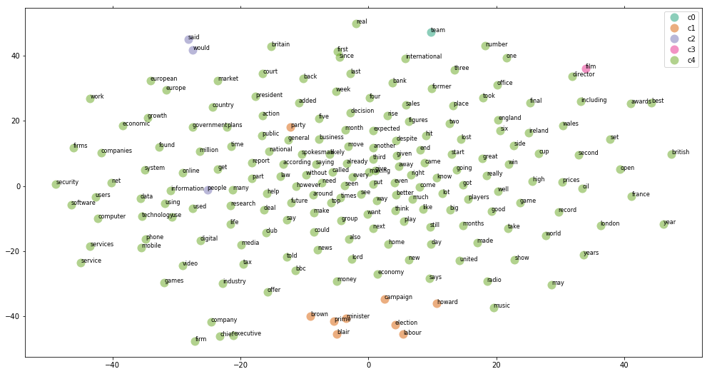

```python
# cluster_viz(df_tfidf, clusters, df_tfidf.T.columns.values.tolist(), True)
tsne_data = graph_tsne(df_tfidf, True, 1)
```

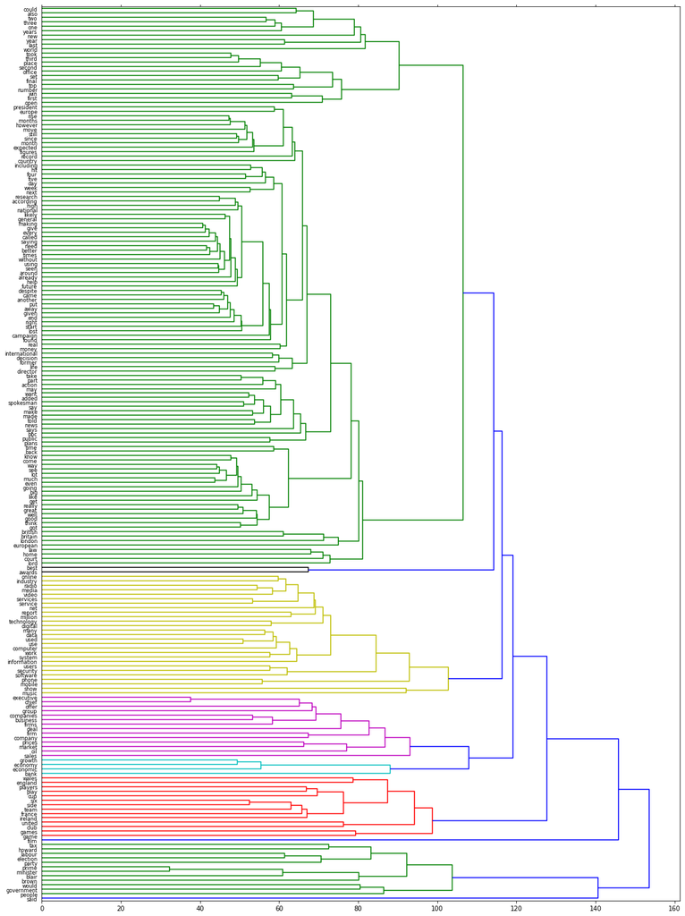

```python
linkage_matrix = ward(tsne_data) #define the linkage_matrix using ward clustering pre-computed distances

fig, ax = plt.subplots(figsize=(15, 20)) # set size
ax = dendrogram(linkage_matrix, orientation="right",
                labels=df_tfidf.index.values.tolist(),
                leaf_font_size=8);

plt.tick_params(\
    axis= 'x',          # changes apply to the x-axis
    which='both',      # both major and minor ticks are affected
    bottom='off',      # ticks along the bottom edge are off
    top='off',         # ticks along the top edge are off
    labelbottom='off')

plt.tight_layout() #show plot with tight layout
```